# Home Prices Rise Slower In Markets That Build More Housing

###### Updated March 2026 with the release of 2025 US Census Population Estimates

This study analyzes market shifts across an eight-year period (2018–2025) and, controlling for population growth, quantifies how new construction directly moderates price appreciation. The results reveal a trend: in six of the last eight years, the addition of a single multifamily unit per thousand residents correlated with a 1% to 2% nominal decrease in the growth rate of price per square foot.

This analysis adds to the growing body of evidence demonstrating that building more new housing is the clear and straightforward solution to the housing affordability problem that has become the single biggest economic issue facing young families, and Americans trying to become parents.

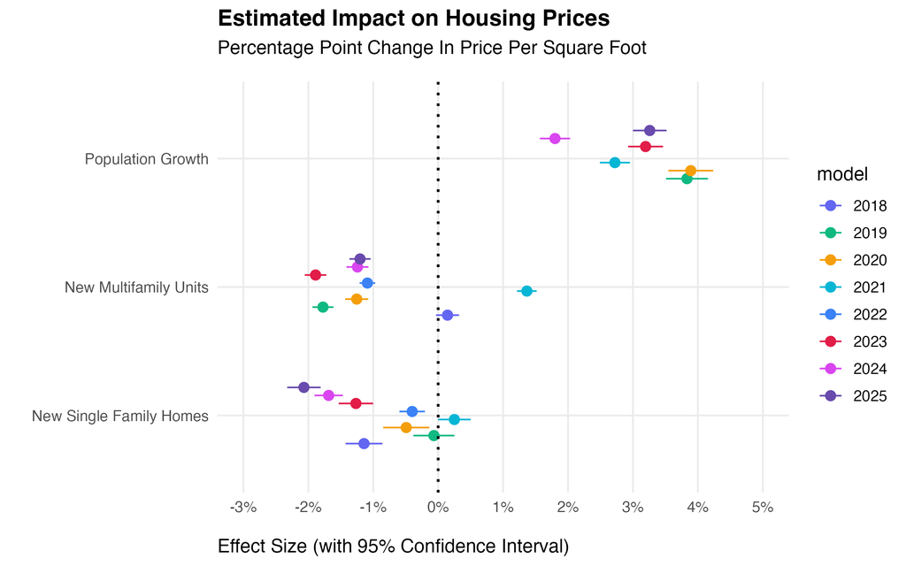

The forest plot above illustrates the effect of new single family homes, multifamily units, and population growth on home prices. This study measures new housing units through building permits issued two years prior. This choice allows for accurate estimates of new housing inventory, and avoids simultaneity bias by using population at the time of permit issuance as the denominator.

There is reason to believe that 2021 was a singular year for home prices, and that the positive relationship in this model for that year is a historical anomaly. For example, home prices increased massively nationwide in 2021 compared to other years within the timespan covered by Redfin housing data, for all counties as well as for large metro areas:

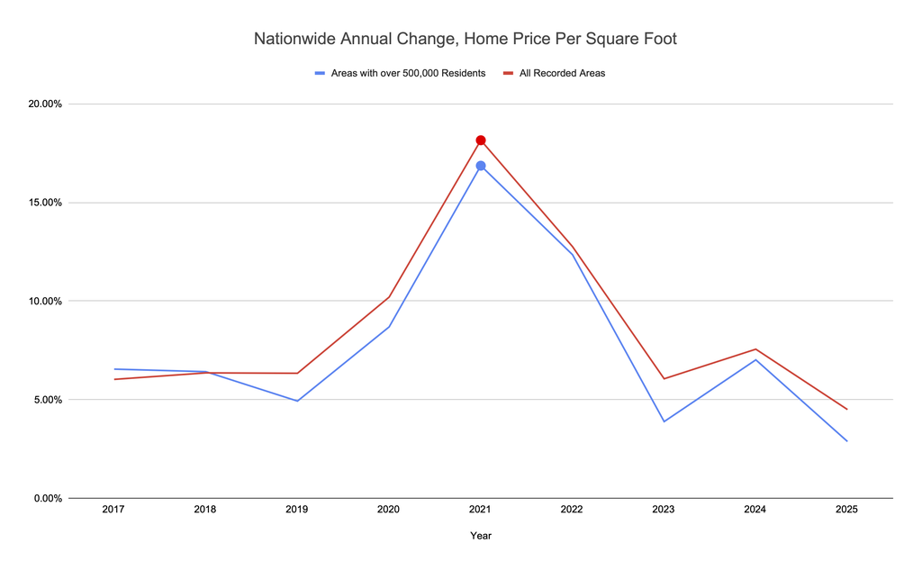

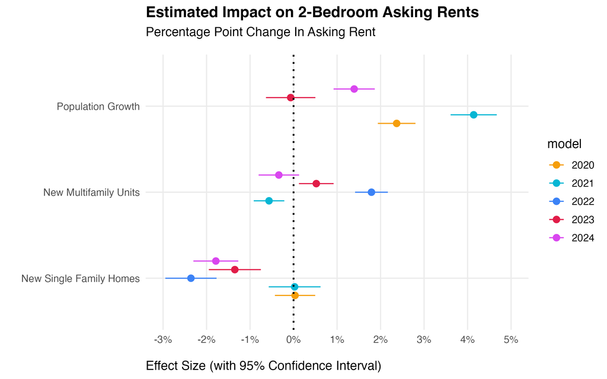

The model shows a negative relationship between new single family homes and asking rents, though it would benefit from a larger sample, in terms of both years and number of markets (n = 41).

**Data Sources:** Housing market statistics provided by Redfin Data Center. Population and building permit data sourced from the U.S. Census Bureau Population Estimates Program (PEP) and Building Permits Survey (BPS).

### Methodology & Technical Implementation Highlights

**Data Orchestration**  
SQL (PostgreSQL): Performed high-volume joins between Redfin’s weekly market TSVs and US Census Bureau population datasets. Developed custom cleaning scripts to resolve geographic naming mismatches across different data vintages (2013 vs. 2023).

Google Sheets: Engineered a functional unpivoting logic using REDUCE and LAMBDA to transform decade-wide Census tables into a relational “long” format for time-series analysis. Applied array and filtering logic to allow for reliable integration of future data.

**Econometric Design**  
Endogeneity & Simultaneity: Mitigated simultaneity bias by utilizing lagged independent variables (t-2). This accounts for the time needed for homes to actually be completed after they are permitted. Additionally, it ensures that the model captures the supply-side impact of building permits on future prices, rather than current price growth driving immediate permitting activity.

Variable Normalization: To ensure comparability across market sizes, all housing permits were scaled to units per 1,000 residents. Conducted robustness checks by splitting the analysis into yearly cross-sections (2018–2025), accounting for time-varying macroeconomic shocks such as interest rate volatility and the 2021 demand spike.

Back-Transformation: Used a custom R function to convert standardized Z-score coefficients back into nominal percentage points, ensuring the findings were interpretable for non-technical stakeholders.

**Model Integrity**  
Outlier Management: Utilized SQL window functions to identify and remove price-per-square-foot anomalies (5x regional mean) that would have biased the regression slopes.

Significance Testing: Applied the modelsummary and fixest packages in R to generate LaTeX-formatted tables with consistent standard error reporting and significance stars.

**Next Steps**  
Data for future years will be released intermittently by the US Census Bureau and Redfin This will allow for a larger body of evidence, and potentially underscore the notion that the 2021 spike was truly an anomaly. A clearer picture of what causes home prices to change could also be discovered through adding metrics such as income.

Code for this analysis is available in the GitHub [repository](https://github.com/Reed-Solomon-9/Housing-Permit-Analysis), and other relevant data is located in my Google Sheets [workbook](https://docs.google.com/spreadsheets/d/1iMcNK9optOYsxhKkWHpMaFekGg6laP4Bg2kJylIvdTc/edit?gid=588298634#gid=588298634).